# Survey Analysis

Nathaniel Bozarth

9/23/2020

## Introduction

In this R Markdown document I analyze the distribution of answers on a 48-item survey. Each item in the survey contributes to the respondent’s score on one or more of ten categories. For the purpose of this analysis, the categories are simply number cat1 - cat10 where “cat” is short for “category”. Items utilize either a five or seven point likert scale. Five point scale and seven point scale items are dealt with separately.

The data to be analyzed includes 2,407 records.

## Item Analysis

Responses to the survey in question garner highly subjective responses. That is, while one respondent may rate themselves very low on a given item, another, from some absolute measure, identical respondent, may rank themselves very differently. Some respondents may have a tendency to score themselves higher than other respondents in the absence of some absolute measure. An analysis of response patterns may illuminate whether certain items include some social desirability component. (That is, do respondents tend to respond to certain items in a way that conforms with perceived norms of goodness or good socialization?)

By analyzing each item in the survey, this analysis represents one means of identifying whether certain items may need to be re-worded or whether differences are *real* differences.

### Item Distribution Analysis

Before making any transformation to correct for respondent tendency or socially favorable responses, this section gives the as-is distribution for each item, using box and whiskers charts.

#### Five Point Item Distribution Analysis

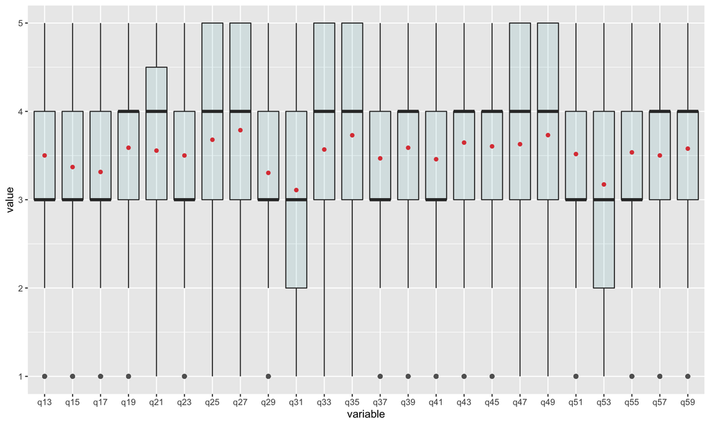

The above plot shows that on the five point items, respondents are more likely to score items high than low. This is clearly seen by the red dot, which represents the mean for each item. For all questions, the mean is above 2.5, the midpoint on the likert scale.

The following questions skew especially high:

- q27
- q35
- q43

These items code for cat5, cat5, and cat7, respectively. Both cat5 and cat7 very frequently rank highest among respondent composite scores (first most frequent and second most frequent, respectively). cat5, however, occurs much less frequently in respondents’ top scored categories than either cat5 or cat7 (10.4% of the time versus 16% and 14.1%, respectively). This would seem to show that other items that code for cat5 counterbalance the frequent positive responses to q35.

THe following items skew especially low:

- q17
- q31
- q53

q17 codes for cat1. q31 codes for cat2. q53 codes for both cat2 and cat9. cat1, cat2 and cat9 are the categories most likely to appear in a respondent’s bottom three categories.

#### 7 Point Item Distribution Analysis

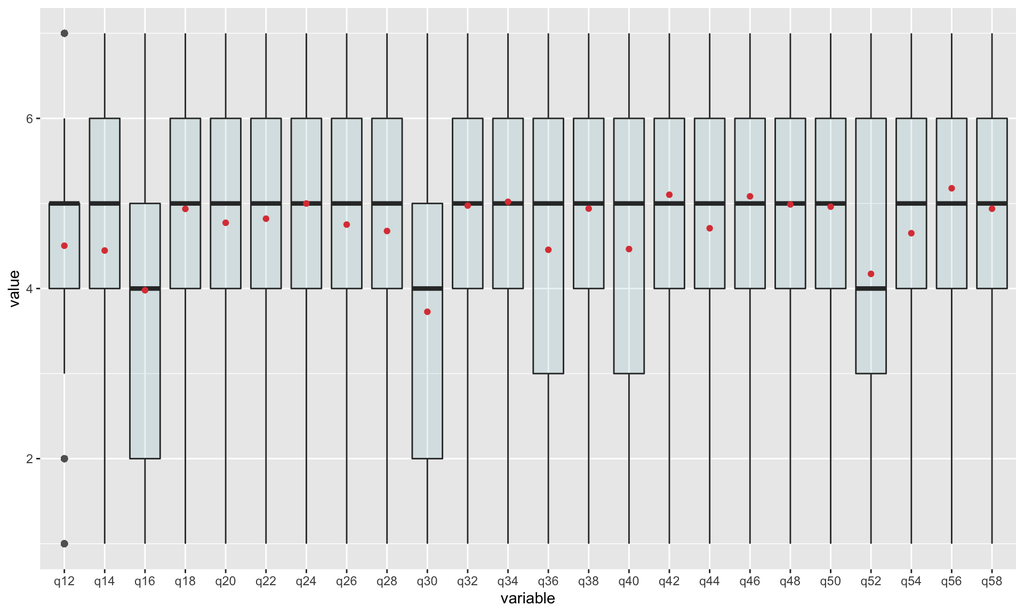

As with the five point scale items on the survey, respondents are more likely to rate themselves highly than lowly on seven point scale items. This is demonstrated by the fact that the median response for most items is five out of seven. A neutral response is represented by four.

One item has an especially low variance among all responses:

- q12

For this item, respondents were highly likely to mark four of five. This item codes for cat1.

- q16
- q30
- q36
- q40
- q52

These questions code for cat1 (q16), cat2 (q30, q52), cat5 (q36), cat6 (q36, q40), and cat9 (q52). The questions in this set coding for cat1 and cat2 have the lowest median response.

q36 seems to be the item that counterbalances the average positive response to q35 (see previous sub-section). The other items in this group represent (code for) the four categories most commonly in respondents’ bottom three categories (cat2, cat1, cat9, and cat6).

### Composite Item Distribution by cat

Each item in the survey codes for one or more categories. This section explores the distribution of composite scores for each category

#### Five Point Composite Item Distribution Analysis

Chart is arranged in descending order of mean composite item value.

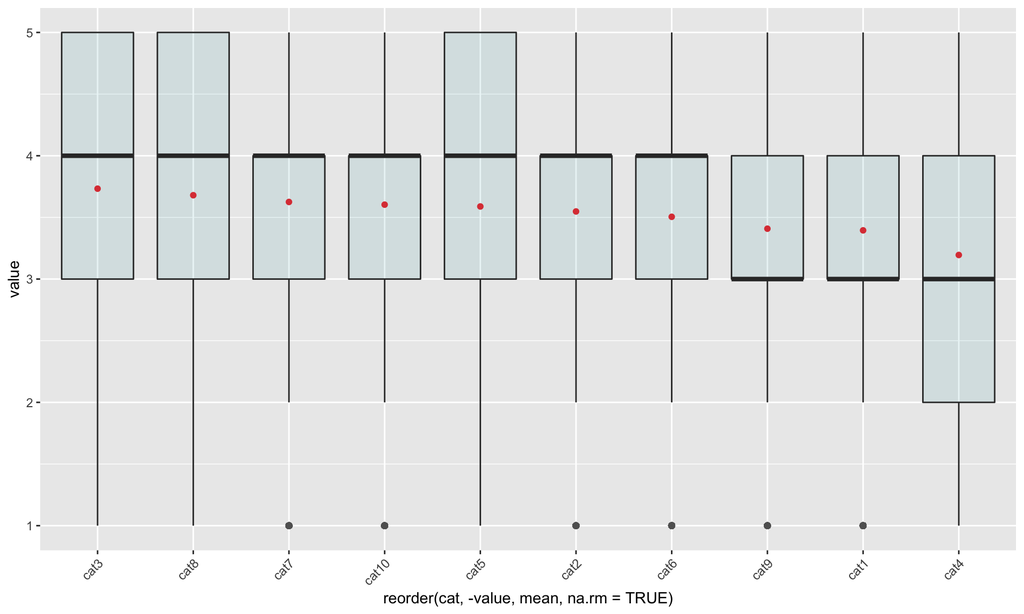

```
## # A tibble: 10 x 2
##    cat    mean
##    <chr> <dbl>
##  1 cat3   3.73
##  2 cat8   3.68
##  3 cat7   3.63
##  4 cat10  3.6
##  5 cat5   3.59
##  6 cat2   3.55
##  7 cat6   3.5
##  8 cat9   3.41
##  9 cat1   3.39
## 10 cat4   3.2
```

The descending mean as rank position of the composite five point scores exactly matches the frequency that each category occurs in the first, second, or third position of a respondent’s ranked categories with the exception of cat9. While cat9 least frequently occurs as a respondent’s top cat, in this rank order, cat9 falls in the third to last position. This would seem to say that respondents on average mark higher responses on 5 point scale items cat9 than they report on 7 point cat9 activities. That is, the self-reported scores that respondents give for 7 point items pulls the overall cat9 scores down.

#### 7 point Composite Item Distribution Analysis

Chart is arranged in descending order of mean composite item value.

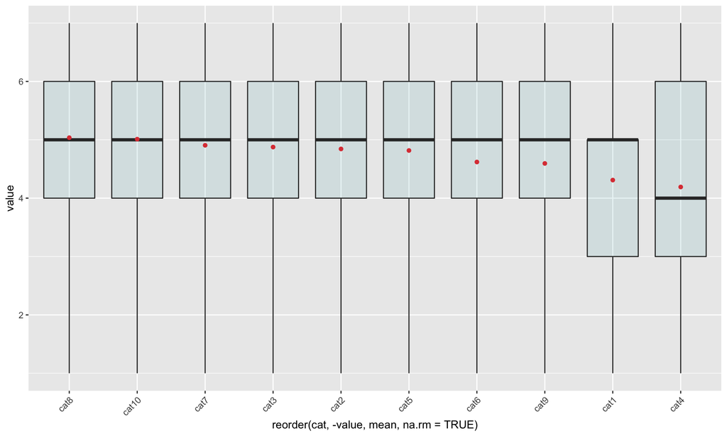

```
## # A tibble: 10 x 2
##    cat    mean
##    <chr> <dbl>
##  1 cat8   5.04
##  2 cat10  5.01
##  3 cat7   4.91
##  4 cat3   4.88
##  5 cat2   4.84
##  6 cat5   4.82
##  7 cat6   4.62
##  8 cat9   4.59
##  9 cat1   4.31
## 10 cat4   4.19
```

Comparing the two composite distributions, it is easy to see that five point scale answers and seven point scale answers are closely correlated.

## Deviating Questions

In this section, scores for each respondent are represented as compared to the respondent’s central tendency (as z-scores).

### Five Point Scale Questions Deviation

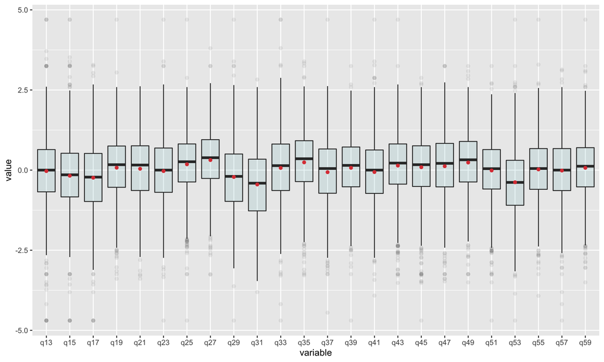

Among five point scale items, respondents tend to deviate most strongly away from their central tendencies on the following items:

- q17 (cat1)
- q31 (cat2)
- q53 (cat2, cat9)

These are the same items whose raw scores skewed lowest.

### Seven Point Scale Item Deviation

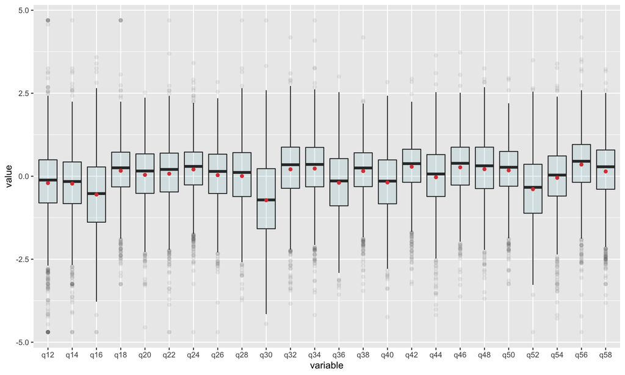

Among seven point scale items, respondents tend to deviate most strongly away from their central tendencies on the following questions:

- q16 (cat1)
- q30 (cat2)
- q52 (cat2, cat9)

Much of the variance that appeared in raw scores on q36 and q40 is no longer apparent.

## Composite Category Deviance

### Composite Item Deviance by Category

### Five Point Scale Item Composite Deviation

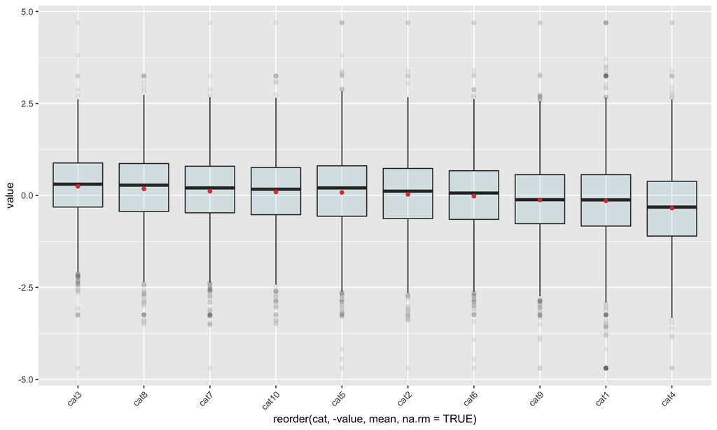

### Seven Point Scale Items Composite Deviation

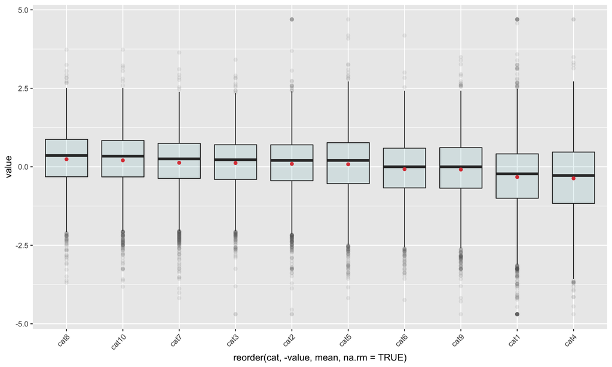

### Category Composites

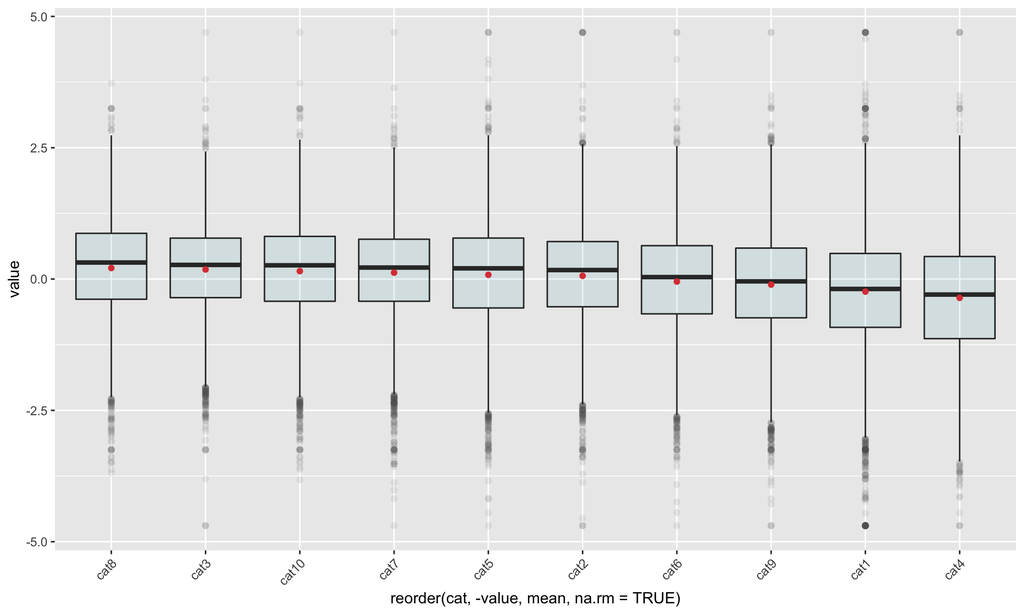

### Summary

In this summary of distribution statistics, the category for which an item codes is listed after the question.

Distribution statistics reveal that several item clusters (both seven point scale and five point scale itemss coding for the same category) are subject to greater variance. For the following items, both the seven point scale and five point scale items have an above average standard deviation:

- Q16 and Q17 (cat1)
- Q30 and Q31 (cat2)
- Q32 and Q33 (cat5)
- Q36 and Q37 (cat5, cat6)

There are three items which respondents tend to rate higher than other items. On these items, the standard deviation is low (signified by *) or average.

- Q27 (cat5)
- Q34 (cat5)
- Q35* (cat5)

For the following item clusters, respondents tend to rate themselves lower than other items. For these items, however, the standard deviation is higher than for other items. These items tend to garner varied responses.

For the purpose of understanding how item bias might introduce error into the survey, it is interesting to note that item clusters coding for categoreis cat1, cat2 and cat9 have high volatility as these three categories occur most frequently among respondents’ bottom three categories. It is predictable that, for two of these clusters of items, the means are also lower than average (cat1 and cat2).

Two item clusters that code for cat5 have anomalous distribution statistics: Q32 and Q33, and Q36 and Q37. cat5 appears in respondents’ top three categories with almost median frequency. Likewise, cat5 appears in respondents’ bottom three categories with almost median frequency.

cat5 represents a surprisingly divisive topic. Compared to other catilties, when it comes to cat5 questions, respondents tend to vary a little more.

## Conclusion

cat1, cat2, and cat5 show slight evidence of some social undesirability/desirability bias.